# Market Basket Analysis

Vamsi Nalluri

## Install the required packages and libraries , as required, at appropriate chunks.

## 1. Importing Data

Load the Online Retail.csv data file into Mydata Variable. Ensure that the dataset is located in the current working directory.

```r
Mydata <- read.csv("Online Retail.csv")
#Using Summary Function to check the descriptive statistics
summary(Mydata)
```

```
##   InvoiceNo          StockCode         Description           Quantity
##  Length:541909      Length:541909      Length:541909      Min.   :-80995.00
##  Class :character   Class :character   Class :character   1st Qu.:     1.00
##  Mode  :character   Mode  :character   Mode  :character   Median :     3.00
##                                                           Mean   :     9.55
##                                                           3rd Qu.:    10.00
##                                                           Max.   : 80995.00
##
##  InvoiceDate          UnitPrice           CustomerID       Country
##  Length:541909      Min.   :-11062.06   Min.   :12346    Length:541909
##  Class :character   1st Qu.:     1.25   1st Qu.:13953    Class :character
##  Mode  :character   Median :     2.08   Median :15152    Mode  :character
##                     Mean   :     4.61   Mean   :15288
##                     3rd Qu.:     4.13   3rd Qu.:16791
##                     Max.   : 38970.00   Max.   :18287
##                                         NA's   :135080
```

```r
#Displaying the first 6 rows of the data
head(Mydata)
```

```
##   InvoiceNo StockCode                         Description Quantity  InvoiceDate
## 1    536365    85123A  WHITE HANGING HEART T-LIGHT HOLDER        6 12/1/10 8:26
## 2    536365     71053                 WHITE METAL LANTERN        6 12/1/10 8:26
## 3    536365    84406B      CREAM CUPID HEARTS COAT HANGER        8 12/1/10 8:26
## 4    536365    84029G KNITTED UNION FLAG HOT WATER BOTTLE        6 12/1/10 8:26
## 5    536365    84029E      RED WOOLLY HOTTIE WHITE HEART.        6 12/1/10 8:26
## 6    536365     22752        SET 7 BABUSHKA NESTING BOXES        2 12/1/10 8:26
##   UnitPrice CustomerID        Country
## 1      2.55      17850 United Kingdom
## 2      3.39      17850 United Kingdom
## 3      2.75      17850 United Kingdom
## 4      3.39      17850 United Kingdom
## 5      3.39      17850 United Kingdom
## 6      7.65      17850 United Kingdom
```

If we carefully inspect the Mydata variable , we see that InvoiceNo includes cancelled transactions where in the InvoiceNo is preceded with a ‘c’. We need to remove those cancelled transactions from the data set to get accurate outcomes (Apiori Rules for the item sets)

Further,both Description and Country columns are of categorical variables and need to be factored in.

There are over 135,000 customer IDs are missing , however, we would not remove them from the data set as the outcome is related to items not the customer profiles (Content based recommender system vs Collaborative system)

## 2. Data Pre-Processing

Removing the cancelled Transactions from the Dataset.

```r
#install.packages("stringr")
library(stringr)

#Calculate the number of cancelled transactions
length(which(substr(str_to_upper(Mydata$InvoiceNo),1,1) == "C"))
```

```
## [1] 9288
```

```r
#Remove the Cancelled transactions and save the remaining transactions to Mydata1
Mydata1 <- Mydata[-which(substr(str_to_upper(Mydata$InvoiceNo),1,1) == "C"),] #just thus active transactions
nrow(Mydata1)
```

```
## [1] 532621
```

After Removing the cancelled transactions , the dataset has 532621 records as against the original 541909 records.

Factoring Description and Country columns

```r
#install.packages("dplyr")
library(dplyr)
Mydata1 <- Mydata1 %>% mutate(Description = as.factor(Description))

Mydata1 <- Mydata1 %>% mutate(Country = as.factor(Country))
glimpse(Mydata1)
```

```
## Rows: 532,621
## Columns: 8
## $ InvoiceNo   <chr> "536365", "536365", "536365", "536365", "536365", "536365"…
## $ StockCode   <chr> "85123A", "71053", "84406B", "84029G", "84029E", "22752", …
## $ Description <fct> "WHITE HANGING HEART T-LIGHT HOLDER", "WHITE METAL LANTERN…
## $ Quantity    <int> 6, 6, 8, 6, 6, 2, 6, 6, 6, 32, 6, 6, 8, 6, 6, 3, 2, 3, 3, …
## $ InvoiceDate <chr> "12/1/10 8:26", "12/1/10 8:26", "12/1/10 8:26", "12/1/10 8…
## $ UnitPrice   <dbl> 2.55, 3.39, 2.75, 3.39, 3.39, 7.65, 4.25, 1.85, 1.85, 1.69…
## $ CustomerID  <int> 17850, 17850, 17850, 17850, 17850, 17850, 17850, 17850, 17…
## $ Country     <fct> United Kingdom, United Kingdom, United Kingdom, United Kin…
```

## 3. Exploratory Data Analysis

Plot the graph that shows the top 10 selling items

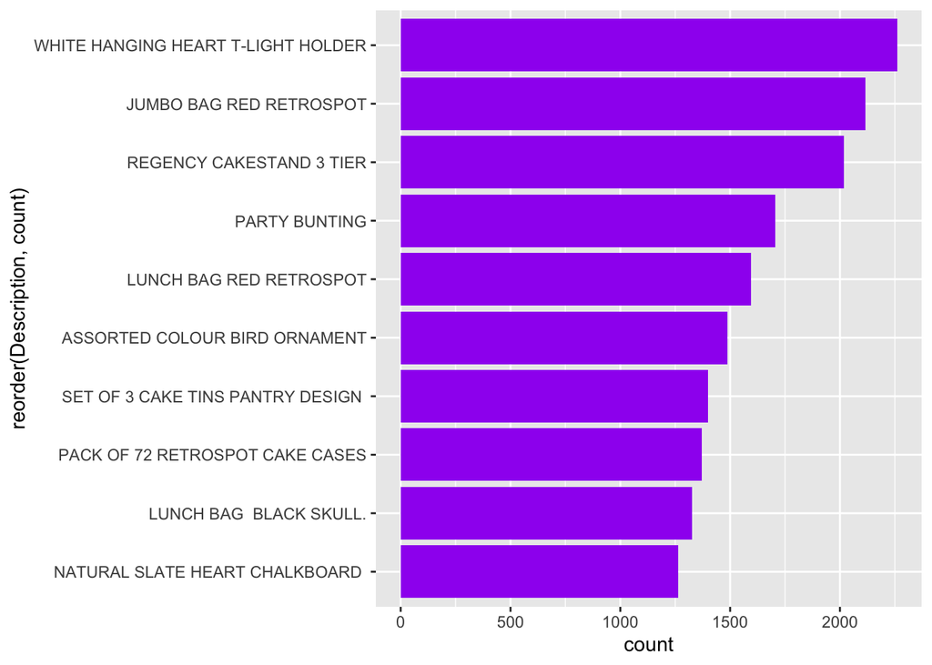

```r
#install.packages("ggplot2")
library(ggplot2)

Mydata2 <- Mydata1 %>% group_by(StockCode, Description) %>% dplyr::summarise(count = n()) %>% arrange(desc(count))
Mydata2 <- head(Mydata2, n=10)
Mydata2 %>% ggplot(aes(x=reorder(Description,count),y=count))+geom_bar(stat="identity",fill="purple")+coord_flip()
```

We can see that some of the top selling items are WHITE HANGING HEART T-LIGHT HOLDER , JUMBO BAG RED RETROSPOT and REGENCY CAKESTAND 3 TIER.

## 4. Association Rules

If we look at the dataset carefully, we can see that invoice numbers are duplicated for wach item in that invoice. Inorder to run the association rules we need to have an invoice number with all the corresponding transaction items in one row (We need to transform the tabular format to transacrtions format).

Split the dataset by Invoice number and date and capture the items for the corresponding invoice number and then remove the Invoice number and Invoice Date as we need only item sets to generate the association rules.

```r
#install.packages("plyr")
library(plyr)
Mydata3 <- ddply(Mydata1, c("InvoiceNo","InvoiceDate"), function(df1)paste(df1$Description, collapse = ","))
#Removing InvoiceNO and InvoiceDate columns
Mydata3$InvoiceNo <- NULL
Mydata3$InvoiceDate <- NULL
colnames(Mydata3) <- c("item sets")
# We will convert the transactions and save it as a csv (File will be saved on to the working directory)
write.csv(Mydata3,"MBA.csv", quote = FALSE, row.names = FALSE)
```

Reading the Transactions from the CSV file using arules package as a basket of transactions in a matrix format (sparse)

```r
#install.packages("arules")
library(arules)
trans <- read.transactions("MBA.csv",quote = "", format = 'basket', sep=',')
summary(trans)
```

```
## transactions as itemMatrix in sparse format with
##  22107 rows (elements/itemsets/transactions) and
##  4239 columns (items) and a density of 0.005595264
##
## most frequent items:
## WHITE HANGING HEART T-LIGHT HOLDER            JUMBO BAG RED RETROSPOT
##                               2260                               2092
##           REGENCY CAKESTAND 3 TIER                      PARTY BUNTING
##                               1989                               1686
##            LUNCH BAG RED RETROSPOT                            (Other)
##                               1564                             514750
##
## element (itemset/transaction) length distribution:
## sizes
##    0    1    2    3    4    5    6    7    8    9   10   11   12   13   14   15
```

[output cut: 54 more lines]

We can notice that there are a total of 22107 transactions and 4239 items that constitute the transactions. We can also notice that most frequent items match with what we have got earlier with ggplot2 function.

Run the Item frequency plot to determine, approximately , the initial support level in the absence of any business rules.

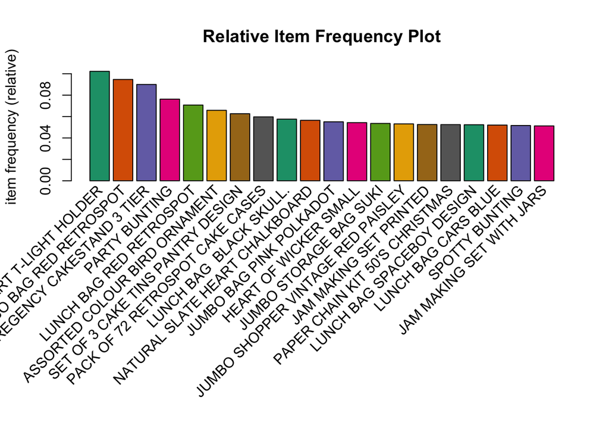

```r
#install.packages("RColorBrewer")
library(RColorBrewer)

# Create an item frequency plot for the top 20 items
itemFrequencyPlot(trans,topN=20,type="relative",col=brewer.pal(8,'Dark2'), main="Relative Item Frequency Plot")
```

Lets generate the apriori rules based on a support of 1% and confidence of 70%.

```r
# Min Support as 0.001, confidence as 0.8.
rules <- apriori(trans, parameter = list(supp=0.01, conf=0.7))
```

```
## Apriori
##
## Parameter specification:
##  confidence minval smax arem  aval originalSupport maxtime support minlen
##         0.7    0.1    1 none FALSE            TRUE       5    0.01      1
##  maxlen target  ext
##      10  rules TRUE
##
## Algorithmic control:
##  filter tree heap memopt load sort verbose
##     0.1 TRUE TRUE  FALSE TRUE    2    TRUE
##
## Absolute minimum support count: 221
##
## set item appearances ...[0 item(s)] done [0.00s].
## set transactions ...[4239 item(s), 22107 transaction(s)] done [0.18s].
## sorting and recoding items ... [716 item(s)] done [0.01s].
## creating transaction tree ... done [0.01s].
## checking subsets of size 1 2 3 4 done [0.03s].
## writing ... [166 rule(s)] done [0.00s].
## creating S4 object  ... done [0.00s].
```

```r
summary(rules)
```

```
## set of 166 rules
##
## rule length distribution (lhs + rhs):sizes
##  2  3  4
## 42 98 26
##
##    Min. 1st Qu.  Median    Mean 3rd Qu.    Max.
##   2.000   2.250   3.000   2.904   3.000   4.000
##
## summary of quality measures:
##     support          confidence        coverage            lift
##  Min.   :0.01004   Min.   :0.7000   Min.   :0.01081   Min.   : 6.931
##  1st Qu.:0.01096   1st Qu.:0.7371   1st Qu.:0.01393   1st Qu.: 8.772
##  Median :0.01206   Median :0.7711   Median :0.01554   Median :17.542
##  Mean   :0.01351   Mean   :0.7933   Mean   :0.01711   Mean   :22.105
##  3rd Qu.:0.01443   3rd Qu.:0.8263   3rd Qu.:0.01865   3rd Qu.:31.139
##  Max.   :0.03474   Max.   :1.0000   Max.   :0.04822   Max.   :61.069
##      count
##  Min.   :222.0
##  1st Qu.:242.2
##  Median :266.5
##  Mean   :298.7
##  3rd Qu.:319.0
##  Max.   :768.0
##
## mining info:
##   data ntransactions support confidence
##  trans         22107    0.01        0.7
##                                                              call
##  apriori(data = trans, parameter = list(supp = 0.01, conf = 0.7))
```

166 rules are generated. Rules may change (increase or decrease) based on the threshold levels (confidence and support) or based on what business managers feel appropriate. Out of 166 rules there are 42 rules for an item length or item set of 2 products in a transaction.

Lets see the top 20 rules

```r
inspect(rules[1:20])
```

```
##      lhs                                   rhs                                     support confidence   coverage      lift count
## [1]  {PAINTED METAL PEARS ASSORTED}     => {ASSORTED COLOUR BIRD ORNAMENT}      0.01171575  0.7000000 0.01673678 10.635670   259
## [2]  {REGENCY SUGAR BOWL GREEN}         => {REGENCY MILK JUG PINK}              0.01099199  0.7546584 0.01456552 50.708915   243
## [3]  {REGENCY MILK JUG PINK}            => {REGENCY SUGAR BOWL GREEN}           0.01099199  0.7386018 0.01488216 50.708915   243
## [4]  {REGENCY SUGAR BOWL GREEN}         => {REGENCY TEAPOT ROSES}               0.01053965  0.7236025 0.01456552 38.453558   233
## [5]  {CANDLEHOLDER PINK HANGING HEART}  => {WHITE HANGING HEART T-LIGHT HOLDER} 0.01275614  0.7085427 0.01800335  6.930864   282
## [6]  {BAKING SET SPACEBOY DESIGN}       => {BAKING SET 9 PIECE RETROSPOT}       0.01510834  0.7182796 0.02103406 17.001078   334
## [7]  {POPPY'S PLAYHOUSE LIVINGROOM}     => {POPPY'S PLAYHOUSE KITCHEN}          0.01185145  0.7987805 0.01483693 40.408788   262
## [8]  {POPPY'S PLAYHOUSE LIVINGROOM}     => {POPPY'S PLAYHOUSE BEDROOM}          0.01176098  0.7926829 0.01483693 41.427521   260
## [9]  {REGENCY TEA PLATE PINK}           => {REGENCY TEA PLATE GREEN}            0.01257520  0.9114754 0.01379654 52.887105   278
## [10] {REGENCY TEA PLATE GREEN}          => {REGENCY TEA PLATE PINK}             0.01257520  0.7296588 0.01723436 52.887105   278
## [11] {REGENCY TEA PLATE PINK}           => {REGENCY TEA PLATE ROSES}            0.01216809  0.8819672 0.01379654 43.814942   269
## [12] {SET OF 6 SNACK LOAF BAKING CASES} => {SET OF 12 FAIRY CAKE BAKING CASES}  0.01144434  0.7146893 0.01601303 28.622528   253
## [13] {SET/6 RED SPOTTY PAPER CUPS}      => {SET/6 RED SPOTTY PAPER PLATES}      0.01583209  0.8177570 0.01936038 34.238928   350
## [14] {TOILET METAL SIGN}                => {BATHROOM METAL SIGN}                0.01325372  0.7234568 0.01831999 23.764427   293
## [15] {SET 3 RETROSPOT TEA}              => {SUGAR}                              0.01945085  1.0000000 0.01945085 51.411628   430
## [16] {SUGAR}                            => {SET 3 RETROSPOT TEA}                0.01945085  1.0000000 0.01945085 51.411628   430
## [17] {SET 3 RETROSPOT TEA}              => {COFFEE}                             0.01945085  1.0000000 0.01945085 43.347059   430
## [18] {COFFEE}                           => {SET 3 RETROSPOT TEA}                0.01945085  0.8431373 0.02306962 43.347059   430
## [19] {SUGAR}                            => {COFFEE}                             0.01945085  1.0000000 0.01945085 43.347059   430
## [20] {COFFEE}                           => {SUGAR}                              0.01945085  0.8431373 0.02306962 43.347059   430
```

## Interpretation:

Note that the rules in the tabular format above are not sorted either by lift or confidence to show variety of data.

For example , looking at row number 15 in the table, because confidence is 1 for the itemset , there is a 100% probability that the customer who buys SET 3 RETROSPOT TEA will also buy SUGAR. Further , lift of 51.41 indicates that the customer purchasing the 2 items together is 51 times higher compared to buying the second item alone.

Based on the understanding of these rules retailers can appropriately display/recommend/advertise the items to the customers.

## Graphical Representation of the top 10 rules

```r
#install.packages("arulesViz")
library(arulesViz)

top10subRules <- head(rules, n = 10, by = "confidence")

plot(top10subRules, method = "graph",  engine = "htmlwidget")
```

[interactive chart not shown]

As we can see above head of the arrow represents rhs of the product and tail of the arrow represents the lhs of the product. Further, bigger bubble represents higher support and the intensity of the colour represents the higher lift.